# RAPTOR

Juan Valencia

11/9/2020

# **Introduction**

Have you ever watched a game of basketball and wondered what the announcers meant by two-way player, rim protector, or the front court. floor general. These terms can be analyzed with RAPTOR. RAPTOR, which stands for Robust Algorithm (using) Player Tracking (and) On/Off Ratings, is a statistic that measures box, on/off, and overall RAPTOR. We can use RAPTOR to compare both players and teams from 1976 to 2020. RAPTOR favors modern NBA players, since basketball has become more analytical. Therefore, players tend to take shots they are more likely to make and defend players they have a better suited to defend. Also, teams are constructed more around team chemistry, which can be analyzed with RAPTOR. The box metric measures the amount of points gained and allowed per 100 possessions. The on/off metric is similar to box, but it also takes into effect the player’s teammates while he is on the court and the player’s teammates while the player is not on the court. Overall RAPTOR(raptor_total) is a combination of 85% of box and 21% of on/off. After all of this you may wonder, “What if I replaced a player with an average player?” This is what WAR measures. WAR, or wins above replacement, measures the wins a player is worth to their team. For reference, the average playing time for players in a normal game is:

```
-Starters: 30-38 minutes

-Bench: 15-25 minutes

-Bench Warmers: 0-10 minutes
```

# **Packages Required**

```r
library(tidyverse) # Load tidyverse
```

```r
library(ggplot2) # Load ggplot to make plots
```

# **Data Preparation**

```r
# Read in RAPTOR by 2020 player data
players_2020 <- read.csv("latest_RAPTOR_by_player.csv")
# Read in RAPTOR by 2020 team data
teams_2020 <- read.csv("latest_RAPTOR_by_team.csv")
# Read in RAPTOR by historical team data
players_hist <- read.csv("historical_RAPTOR_by_team.csv")
```

This data was obtained from https://github.com/fivethirtyeight/data/tree/master/nba-raptor .

# **Exploratory Data Analysis**

The first data we will use is the “latest_RAPTOR_by_player.csv”, which is the data for the 2019-2020 season.The season was suspended early due to COVID, so teams we only able to play 63-67 games, as opposed 82 games in a normal season.

```r
players_2020 <- subset(players_2020, select = -c(predator_offense,predator_defense,predator_total,pace_impact))

glimpse(players_2020)
```

```
## Rows: 530
## Columns: 17
## $ player_name          <chr> "Jaylen Adams", "Steven Adams", "Bam Adebayo",...
## $ player_id            <chr> "adamsja01", "adamsst01", "adebaba01", "aldril...
## $ season               <int> 2020, 2020, 2020, 2020, 2020, 2020, 2020, 2020...
## $ poss                 <int> 43, 3964, 6336, 3648, 31, 1288, 1578, 4197, 25...
## $ mp                   <int> 21, 1890, 3104, 1754, 13, 591, 718, 1984, 117,...
## $ raptor_box_offense   <dbl> 2.0231403, 0.3825434, -0.9479613, -0.5268696, ...
## $ raptor_box_defense   <dbl> 4.19800473, 1.90452101, 2.33824732, 1.08096656...
## $ raptor_box_total     <dbl> 6.2211451, 2.2870644, 1.3902860, 0.5540970, -9...
## $ raptor_onoff_offense <dbl> 21.09359108, -0.08952358, 3.56656133, -0.82481...
## $ raptor_onoff_defense <dbl> 19.3538834, 0.2474047, 1.2444605, -0.8843753, ...
## $ raptor_onoff_total   <dbl> 40.4474745, 0.1578811, 4.8110218, -1.7091945, ...
## $ raptor_offense       <dbl> 6.20769034, 0.31579672, -0.10394862, -0.660439...
## $ raptor_defense       <dbl> 7.6562980, 1.6574080, 2.2266522, 0.7770190, -3...
## $ raptor_total         <dbl> 13.8639883, 1.9732047, 2.1227036, 0.1165792, -...
## $ war_total            <dbl> 0.18028882, 4.54277468, 7.75591619, 2.53091737...
## $ war_reg_season       <dbl> 0.00000000, 4.32982299, 5.31119544, 2.53091737...
## $ war_playoffs         <dbl> 0.18028882, 0.21295169, 2.44472074, 0.00000000...
```

Best offensive player by RAPTOR

```r
players_2020 %>% select(player_name,mp,raptor_offense) %>% arrange(desc(raptor_offense)) %>% head(1)#We want to look at the player with the highest offensive RAPTOR rating.
```

```
##      player_name mp raptor_offense
## 1 Jamal Crawford  6       26.40692
```

If you’re not a fan of basketball, you may be thinking that Jamal Crawford is the best basketball player in the NBA since he by far has the best score. The problem with this is that he hasn’t played enough minutes to properly calculate his impact to the game. In order to fix this we need to adjust the minutes played to truly get the best players.

```r
best.players2020 <- players_2020 %>% filter(mp >= 1890) # 1,890 minutes is the average play time of a core player at 30 minutes per game in an 63 game season

best.players2020 %>% select(player_name,raptor_offense) %>% arrange(desc(raptor_offense)) %>% head(1)
```

```
##    player_name raptor_offense
## 1 James Harden       8.488456
```

Now we can clearly see that James Harden is the best offensive player when the minutes are adjusted. For James Harden to also be considered a two-way player he would need to have a positive impact on defense.

Since on/off measures the effect the player’s teammates have while a player is on the court and the player’s teammates while the player is not on the court, we can use on/off to show which player makes his teammates better.

```r
best.players2020 %>% select(player_name, raptor_onoff_total) %>% arrange(desc(raptor_onoff_total)) %>% head(10)
```

```
##              player_name raptor_onoff_total
## 1           LeBron James          10.076597
## 2  Giannis Antetokounmpo           9.090994
## 3          Kawhi Leonard           8.096290
## 4           Jayson Tatum           7.119151
## 5           Jamal Murray           6.794509
## 6        Duncan Robinson           6.770501
## 7          Pascal Siakam           6.339986
## 8        Dennis Schroder           6.317322
## 9           James Harden           6.176286
## 10           Rudy Gobert           5.552609
```

From this, we can see LeBron James has the most positive impact to his teammates. He is what is considered a floor general, since he is able to impact his teammates in a positive way.

What is difference in WAR between the regular season and the playoffs?

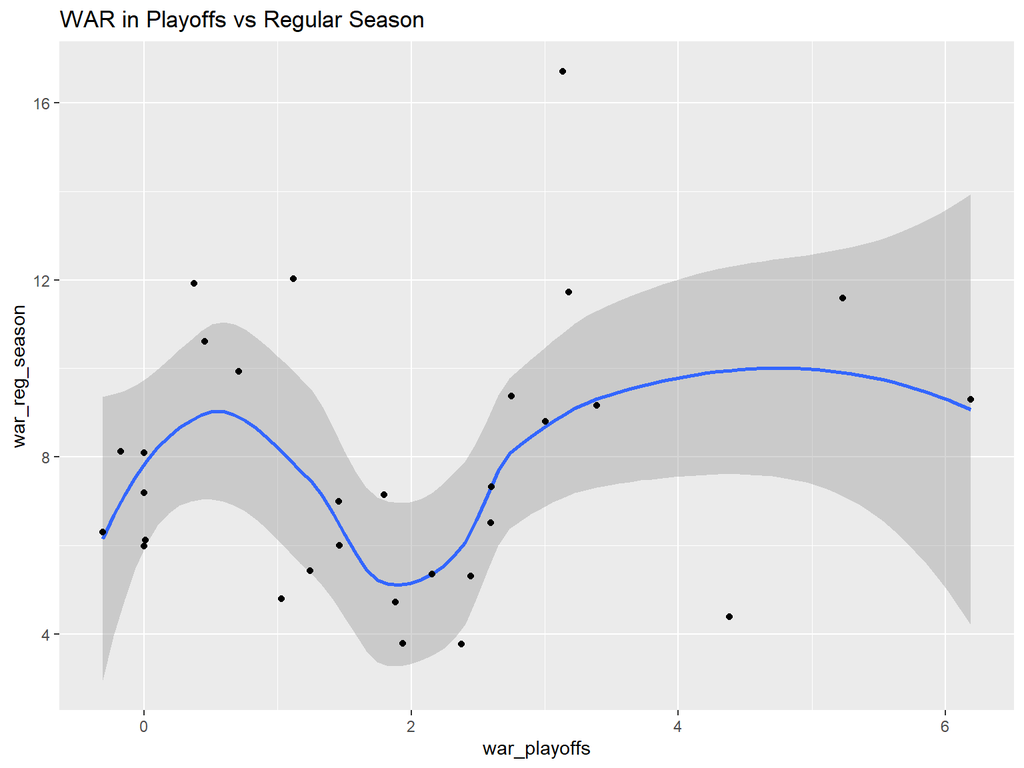

```r
best.players2020 %>% arrange(desc(war_total)) %>% filter(mp > 1890) %>% head(30) %>% ggplot(aes(x = war_playoffs, y = war_reg_season)) + geom_smooth() + geom_point() + ggtitle("WAR in Playoffs vs Regular Season")
```

```r
teams_2020 <- subset(teams_2020, select = -c(predator_offense,predator_defense,predator_total,pace_impact))

glimpse(teams_2020)
```

```
## Rows: 808
## Columns: 19
## $ player_name          <chr> "Jaylen Adams", "Steven Adams", "Steven Adams"...
## $ player_id            <chr> "adamsja01", "adamsst01", "adamsst01", "adebab...
## $ season               <int> 2020, 2020, 2020, 2020, 2020, 2020, 2020, 2020...
## $ season_type          <chr> "PO", "PO", "RS", "PO", "RS", "RS", "RS", "RS"...
## $ team                 <chr> "POR", "OKC", "OKC", "MIA", "MIA", "SAS", "MIA...
## $ poss                 <int> 43, 442, 3522, 1383, 4953, 3648, 31, 1288, 157...
## $ mp                   <int> 21, 210, 1680, 687, 2417, 1754, 13, 591, 718, ...
## $ raptor_box_offense   <dbl> 2.0231403, -0.9363903, 0.5480655, 0.4549766, -...
## $ raptor_box_defense   <dbl> 4.19800473, 3.19804930, 1.74218724, 2.34091036...
## $ raptor_box_total     <dbl> 6.2211451, 2.2616590, 2.2902527, 2.7958870, 0....
## $ raptor_onoff_offense <dbl> 21.0935911, -8.4450755, 0.9590721, 5.8354788, ...
## $ raptor_onoff_defense <dbl> 19.353883437, -5.085708800, 0.916693782, 2.599...
## $ raptor_onoff_total   <dbl> 40.4474745, -13.5307843, 1.8757659, 8.4352404,...
## $ raptor_offense       <dbl> 6.20769034, -2.44639677, 0.66244338, 1.5330035...
## $ raptor_defense       <dbl> 7.6562980, 1.6353479, 1.6601764, 2.5051222, 2....
## $ raptor_total         <dbl> 13.8639883, -0.8110489, 2.3226198, 4.0381258, ...
## $ war_total            <dbl> 0.18028882, 0.21295169, 4.32982299, 2.44472074...
## $ war_reg_season       <dbl> 0.00000000, 0.00000000, 4.32982299, 0.00000000...
## $ war_playoffs         <dbl> 0.18028882, 0.21295169, 0.00000000, 2.44472074...
```

We can take the teams 2020 data to look at the performances of players in the playoffs?

```r
PO_teams <- teams_2020 %>% filter(season_type =="PO") %>% filter(mp >=1)
PO_teams %>% head(10)
```

```
##              player_name player_id season season_type team poss  mp
## 1           Jaylen Adams adamsja01   2020          PO  POR   43  21
## 2           Steven Adams adamsst01   2020          PO  OKC  442 210
## 3            Bam Adebayo adebaba01   2020          PO  MIA 1383 687
## 4          Jarrett Allen allenja01   2020          PO  BRK  279 132
## 5        Justin Anderson anderju01   2020          PO  BRK   61  28
## 6  Giannis Antetokounmpo antetgi01   2020          PO  MIL  602 277
## 7        Carmelo Anthony anthoca01   2020          PO  POR  379 176
## 8             OG Anunoby anunoog01   2020          PO  TOR  806 393
## 9          D.J. Augustin augusdj01   2020          PO  ORL  281 128
## 10            J.J. Barea bareajo01   2020          PO  DAL   12   5
##    raptor_box_offense raptor_box_defense raptor_box_total raptor_onoff_offense
## 1           2.0231403          4.1980047        6.2211451           21.0935911
## 2          -0.9363903          3.1980493        2.2616590           -8.4450755
## 3           0.4549766          2.3409104        2.7958870            5.8354788
```

[output cut: 29 more lines]

Who is the most valuable player for their team in the 2020 playoffs?

```r
PO_teams %>% select(player_name,team,season_type,mp,raptor_onoff_total) %>% filter(mp >= 140) %>% group_by(team) %>% slice(which.max(raptor_onoff_total)) # 140 minutes is the min number of minutes to have the best player of the 16 playoff teams.
```

```
## # A tibble: 16 x 5
## # Groups:   team [16]
##    player_name      team  season_type    mp raptor_onoff_total
##    <chr>            <chr> <chr>       <int>              <dbl>
##  1 Marcus Smart     BOS   PO            648               7.76
##  2 Caris LeVert     BRK   PO            140              -2.88
##  3 Seth Curry       DAL   PO            173              17.8
##  4 Jamal Murray     DEN   PO            753              14.1
##  5 James Harden     HOU   PO            448              10.8
##  6 Malcolm Brogdon  IND   PO            160              11.6
##  7 Ivica Zubac      LAC   PO            320              18.9
##  8 Anthony Davis    LAL   PO            769              11.6
##  9 Goran Dragic     MIA   PO            553               9.87
## 10 Khris Middleton  MIL   PO            355              10.8
## 11 Dennis Schroder  OKC   PO            227              20.8
## 12 Nikola Vucevic   ORL   PO            185              -3.72
## 13 Josh Richardson  PHI   PO            144              13.1
## 14 Damian Lillard   POR   PO            143              -1.86
## 15 Serge Ibaka      TOR   PO            251               8.00
## 16 Donovan Mitchell UTA   PO            264              14.8
```

What if you wanted to compare how valuable Michael Jordan was to the Bulls?

```r
#removed unneeded data
players_hist <- subset(players_hist, select = -c(predator_offense,predator_defense,predator_total,pace_impact))
glimpse(players_hist)
```

```
## Rows: 27,371
## Columns: 13
## $ player_name    <chr> "Alaa Abdelnaby", "Alaa Abdelnaby", "Alaa Abdelnaby"...
## $ player_id      <chr> "abdelal01", "abdelal01", "abdelal01", "abdelal01", ...
## $ season         <int> 1991, 1991, 1992, 1992, 1993, 1993, 1993, 1994, 1995...
## $ season_type    <chr> "PO", "RS", "PO", "RS", "PO", "RS", "RS", "RS", "RS"...
## $ team           <chr> "POR", "POR", "POR", "POR", "BOS", "MIL", "BOS", "BO...
## $ poss           <int> 26, 614, 50, 1948, 128, 322, 2304, 320, 926, 58, 102...
## $ mp             <int> 13, 290, 25, 934, 68, 159, 1152, 159, 476, 30, 467, ...
## $ raptor_offense <dbl> -6.5655561, -3.8272040, -5.4308384, -2.4800046, -9.7...
## $ raptor_defense <dbl> -1.9996253, -0.4470010, -3.1128619, -0.1231248, -3.5...
## $ raptor_total   <dbl> -8.5651814, -4.2742051, -8.5437003, -2.6031294, -13....
## $ war_total      <dbl> -0.03902819, -0.22616282, -0.07721460, 0.07032163, -...
## $ war_reg_season <dbl> 0.00000000, -0.22616282, 0.00000000, 0.07032163, 0.0...
## $ war_playoffs   <dbl> -0.03902819, 0.00000000, -0.07721460, 0.00000000, -0...
```

This data shows the RAPTOR data from 1976-2019. This data is less accurate since the game changed over the years. For example, players today are more efficient at shooting three pointers, which puts more value in players who play the guard position. In the 70s,80s, and 90s, two-pointers were more valuable, so centers were more valuable. This data does not show the position of the players, but we can still show value irregardless of the era they played in. It is also limited to only show RAPTOR and WAR.

Now we can show how valuable Michael Jordan was compared to his teammates in his best season, the 1995-1996 season, for the playoffs and regular season.

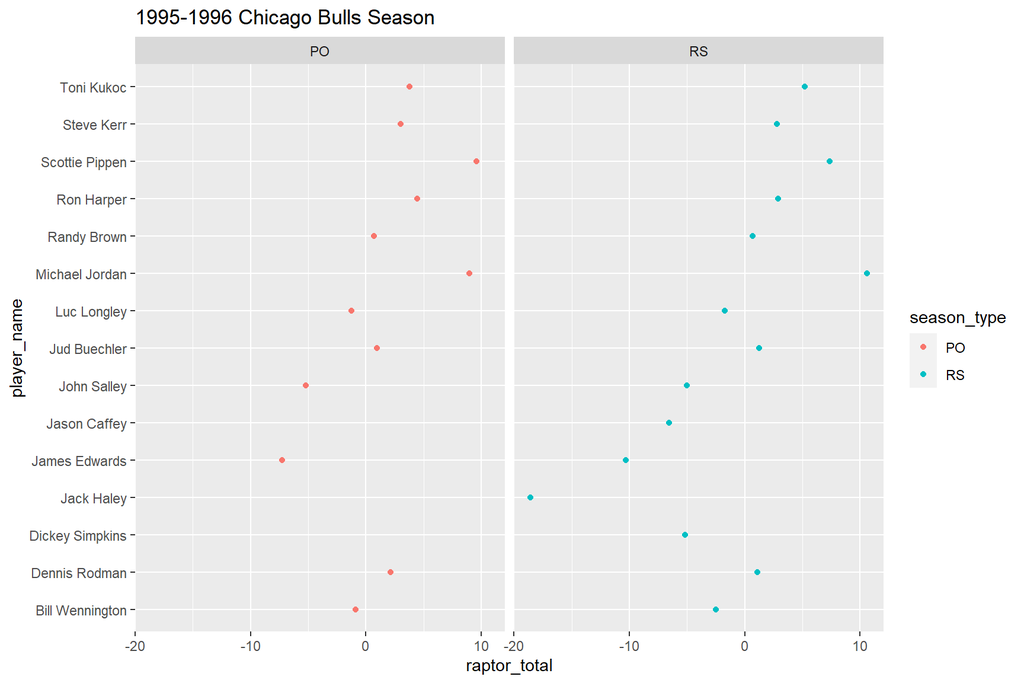

```r
# filter data for only the 1995-1996 Chicago Bulls season
ggplot(data = players_hist %>%  filter(team == "CHI",season == 1996),aes(x = raptor_total,y = player_name, color = season_type)) + geom_point() + facet_wrap(~season_type) + ggtitle("1995-1996 Chicago Bulls Season")
```

```r
# filter data for only Michael Jordan and Scottie Pippen
MJ_v_SP <- players_hist %>%  filter(team == "CHI",season == 1996) %>% arrange(desc(raptor_total)) %>% head(4)
MJ_v_SP %>% arrange(season_type)
```

```
##      player_name player_id season season_type team poss   mp raptor_offense
## 1 Scottie Pippen pippesc01   1996          PO  CHI 1357  742       5.140346
## 2 Michael Jordan jordami01   1996          PO  CHI 1341  733       7.187313
## 3 Michael Jordan jordami01   1996          RS  CHI 5932 3090       7.750829
## 4 Scottie Pippen pippesc01   1996          RS  CHI 5423 2825       5.123616
##   raptor_defense raptor_total war_total war_reg_season war_playoffs
## 1       4.448769     9.589115  4.817561        0.00000     4.817561
## 2       1.790909     8.978222  4.502519        0.00000     4.502519
## 3       2.857449    10.608278 20.969545       20.96954     0.000000
## 4       2.233585     7.357201 14.549173       14.54917     0.000000
```

We can see that Michael Jordan was the best player during the regular season, but was slightly less impactful than Scottie Pippen overall in the playoffs.

With all the success that teams have had throughout their existence, you may think the overall sum of the RAPTOR for a team would be very high, but this is not the case.

```r
players_hist %>% group_by(team) %>% summarise(sum_raptor = sum(raptor_total),sum_mp = sum(mp)) %>% arrange(desc(sum_mp)) %>% head(30)
```

```
## # A tibble: 30 x 3
##    team  sum_raptor sum_mp
##    <chr>      <dbl>  <int>
##  1 LAL       -1390. 951412
##  2 SAS       -1068. 937317
##  3 BOS       -1365. 933611
##  4 HOU       -1314. 912145
##  5 CHI       -1497. 911488
##  6 PHI       -1945. 907980
##  7 DET       -1435. 905898
##  8 POR       -1435. 904848
##  9 PHO       -1528. 899892
## 10 IND       -1133. 897310
## # ... with 20 more rows
```

Here we can see that the Lakers, who have won 11 championships during this time, have a negative overall RAPTOR. How can this be?

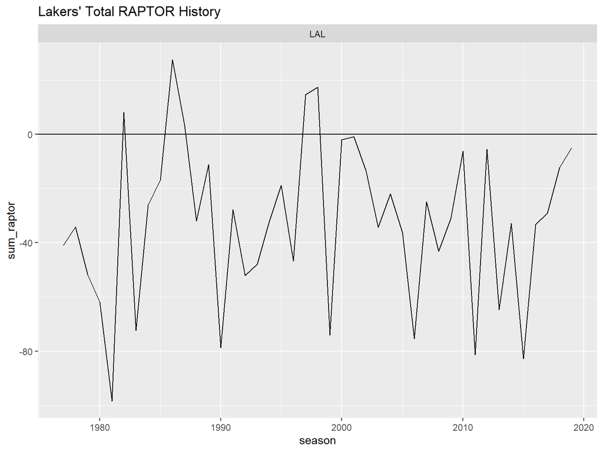

```r
# created a RAPTOR data frame that is the sum of RAPTOR for each season
team_raptor <- players_hist %>% group_by(season,team) %>% summarise(sum_raptor = sum(raptor_total),sum_mp = sum(mp)) %>% arrange(desc(team))
ggplot(data = team_raptor %>% group_by(season) %>% filter(team == "LAL"), aes(x = season, y = sum_raptor)) + geom_line() + facet_wrap(~team) + geom_hline(yintercept = 0) + ggtitle("Lakers' Total RAPTOR History")
```

Now we can clearly see that while the are a successful team, they are not immune to having bad players or bad seasons that will drag down their RAPTOR.

What if you wanted to compare the players from 2020 to players from a different season? We can now use full_join to combine both team data frames to include the seasons from 1976-2020 to compare the players of today with players of the past.

```r
full_team_data <- full_join(players_hist, teams_2020) # full_join combines the data frames
full_team_data <- full_team_data %>% select(player_name,player_id,season,season_type,team,poss,mp,raptor_offense,raptor_defense,raptor_total,war_reg_season,war_reg_season,war_total) # selecting only data with values
```

Now we can show the offensive trend over the history of the NBA.

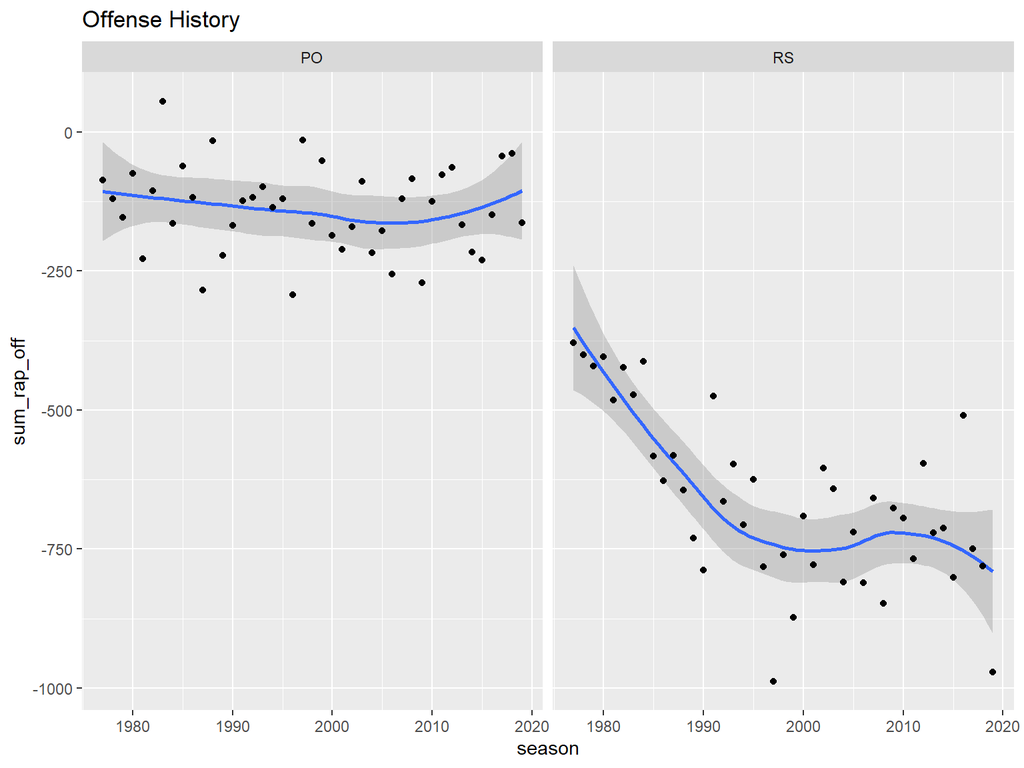

```r
all_team_raptor <- players_hist %>% group_by(season,season_type) %>% summarise(sum_rap_off = sum(raptor_offense)) %>% arrange(desc(season))
#
ggplot(data = all_team_raptor, aes(x = season, y = sum_rap_off)) + geom_smooth() + geom_point() + facet_wrap(~season_type) + ggtitle("Offense History")
```

While the offense looks to have gotten worse over the years, the playoffs have stayed consistent throughout. This information can be used to by teams to choose to rest players in the regular season and have them ready to go in the playoffs, since regular season performance has little to no impact on the a team’s offense.

# **Summary**

This data has been changing the way basketball is analyzed. Data that can compare a player to a player from the past can mean the difference between drafting a future Hall of Famer or a potential bust. A General Manager for a team can use this data to evaluate potential or even team chemistry. We saw that a player who looks great offensively can actually be misleading, as we saw with Jamal Crawford. We can also use this data to help determine NBA MVP(most valuable player), MIP(most improved player), DPOY(defensive player of the year), and even COY(coach of the year). The NBA awards are being scrutinized more every year with analytics and could one day be determined solely on analytics. The NBA teams analyze their players to put them in the best situations to perform, which could be team chemistry, helping a player work to take certain shots, or even when to rest players to prepare for the playoffs. RAPTOR is able to do all that and more, and will also allow the NBA to become a more competitive league.